# Estadística Multivariante. Práctica final.

Xu, Francisco y Gabriel

2023-01-09

Cargamos nuestro csv:

```r
datos <- read.csv("diabetes.csv")
original_datos <- datos
```

## Análisis exploratorio univariante

Con la función summary, podemos ver las medidas de dispersión:

```r
summary(datos)
```

```
##   Pregnancies        Glucose      BloodPressure    SkinThickness
##  Min.   : 0.000   Min.   :  0.0   Min.   :  0.00   Min.   : 0.00
##  1st Qu.: 1.000   1st Qu.: 99.0   1st Qu.: 62.00   1st Qu.: 0.00
##  Median : 3.000   Median :117.0   Median : 72.00   Median :23.00
##  Mean   : 3.845   Mean   :120.9   Mean   : 69.11   Mean   :20.54
##  3rd Qu.: 6.000   3rd Qu.:140.2   3rd Qu.: 80.00   3rd Qu.:32.00
##  Max.   :17.000   Max.   :199.0   Max.   :122.00   Max.   :99.00
##     Insulin           BMI        DiabetesPedigreeFunction      Age
##  Min.   :  0.0   Min.   : 0.00   Min.   :0.0780           Min.   :21.00
##  1st Qu.:  0.0   1st Qu.:27.30   1st Qu.:0.2437           1st Qu.:24.00
##  Median : 30.5   Median :32.00   Median :0.3725           Median :29.00
##  Mean   : 79.8   Mean   :31.99   Mean   :0.4719           Mean   :33.24
##  3rd Qu.:127.2   3rd Qu.:36.60   3rd Qu.:0.6262           3rd Qu.:41.00
##  Max.   :846.0   Max.   :67.10   Max.   :2.4200           Max.   :81.00
##     Outcome
##  Min.   :0.000
##  1st Qu.:0.000
##  Median :0.000
##  Mean   :0.349
##  3rd Qu.:1.000
##  Max.   :1.000
```

Veamos los outliers existentes apoyándonos en boxplot:

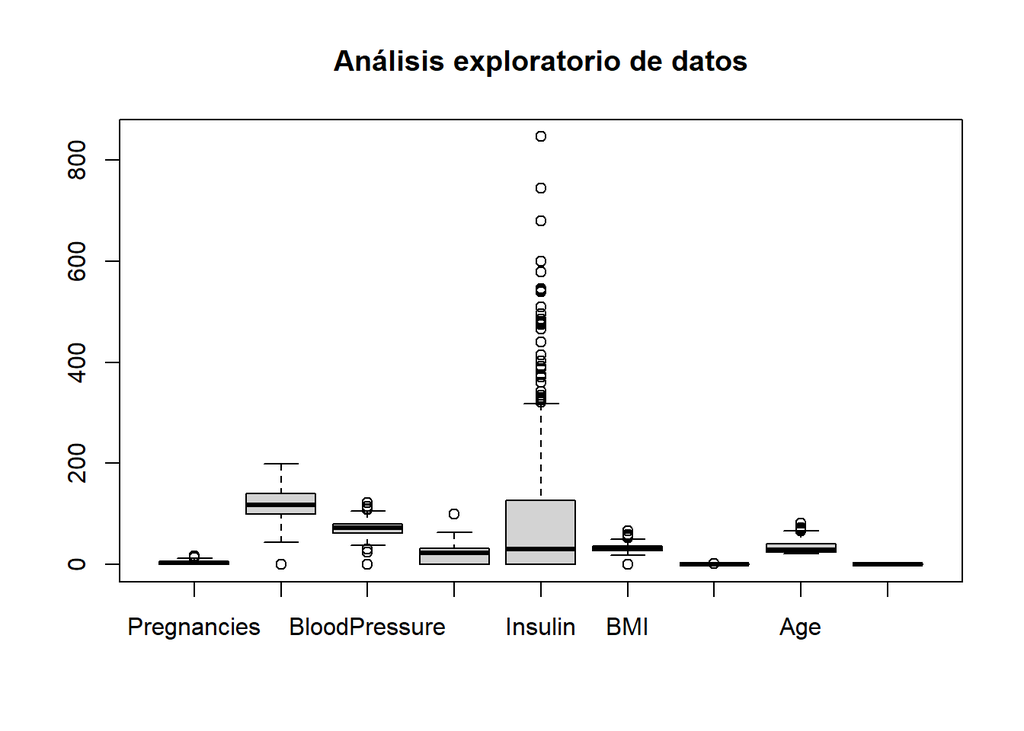

```r
par(mfrow=c(1,1))
boxplot(original_datos, main="Análisis exploratorio de datos")
```

Sustituimos estos outliers por la media con la siguiente función:

```r
outlier2<-function(data,na.rm=T) {
  H<-1.5*IQR(data)

  data[data<quantile(data,0.25,na.rm = T)-H]<-NA

  data[data>quantile(data,0.75, na.rm = T)+H]<-NA

  data[is.na(data)]<-mean(data, na.rm = T)

  H<-1.5*IQR(data)

  if (TRUE %in% (data<quantile(data,0.25,na.rm = T)-H) | TRUE %in% (data>quantile(data,0.75,na.rm = T)+H))
    outlier2(data)
  else
    return(data)
}
```

```r
  for(i in 1:ncol(datos)){
    datos[,i] <- outlier2(datos[,i])
  }
```

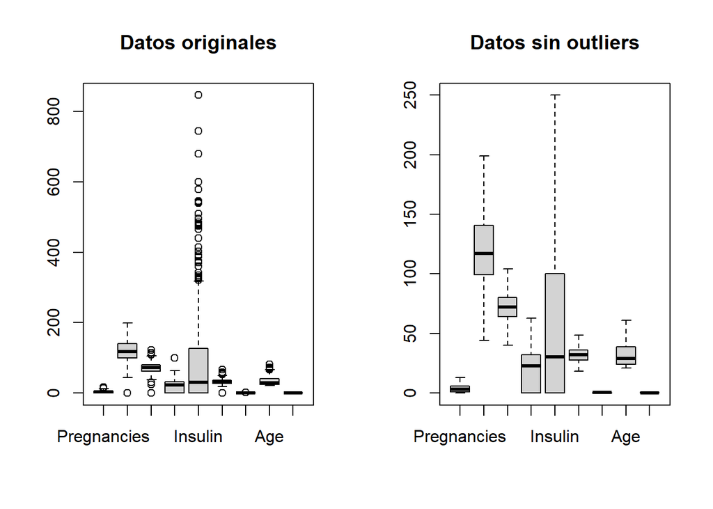

```r
  par(mfrow=c(1,2))
  boxplot(original_datos, main="Datos originales")
  boxplot(datos, main="Datos sin outliers")
```

**Distribuciones individuales**

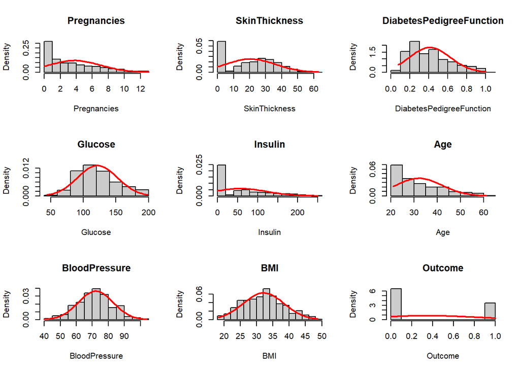

```r
# Representación mediante Histograma
par(mfcol = c(3, 3))
for (k in 1:ncol(datos)) {
  j0 <- names(datos)[k]
    x0 <- seq(min(datos[, k]), max(datos[, k]), le = 50)
    x <- datos[,k]
    hist(x, proba = T, col = grey(0.8), main = j0, xlab = j0)
    lines(x0, dnorm(x0, mean(x), sd(x)), col = "red", lwd = 2)
}
```

**Gráficos qqplots**

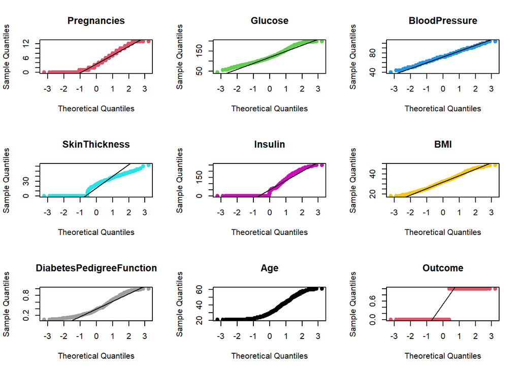

```r
# Representación de cuantiles normales de cada variable
par(mfrow=c(3,3))
for (k in 1:ncol(datos)) {
  j0 <- names(datos)[k]
  x <- datos[,k]
  qqnorm(x, main = j0, pch = 19, col=k+1)
  qqline(x)
}
```

Si bien este análisis exploratorio puede darnos una idea de la posible normalidad o no de las variables univariadas, siempre es mejor hacer los respectivos test de normalidad.

**Test de normalidad univariantes (Shapiro-Wilk)**

```r
datos_tidy <- melt(datos, value.name = "valor", id.vars= NULL)
aggregate(valor~variable, data=datos_tidy, FUN = function(x){shapiro.test(x)$p.value})
```

```
##                   variable        valor
## 1              Pregnancies 2.827729e-21
## 2                  Glucose 1.776816e-11
## 3            BloodPressure 9.951792e-03
## 4            SkinThickness 1.928628e-21
## 5                  Insulin 2.554238e-29
## 6                      BMI 1.182835e-04
## 7 DiabetesPedigreeFunction 2.361120e-17
## 8                      Age 1.353793e-22
## 9                  Outcome 1.292690e-38
```

## Análisis exploratorio multivariante

**Análisis de la correlación**

Si las variables no guardan ninguna correlación, no tendría sentido aplicar técnicas como ACP o AF, po lo que el primer paso es comprobar esto.

Primero, veamos la presencia de correlación gráficamente:

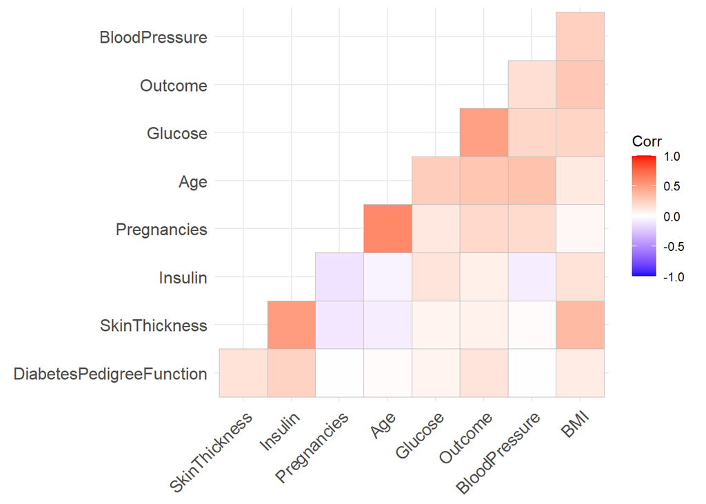

```r
poly_cor<-hetcor(datos)$correlations
ggcorrplot(poly_cor, type="lower",hc.order=T)
```

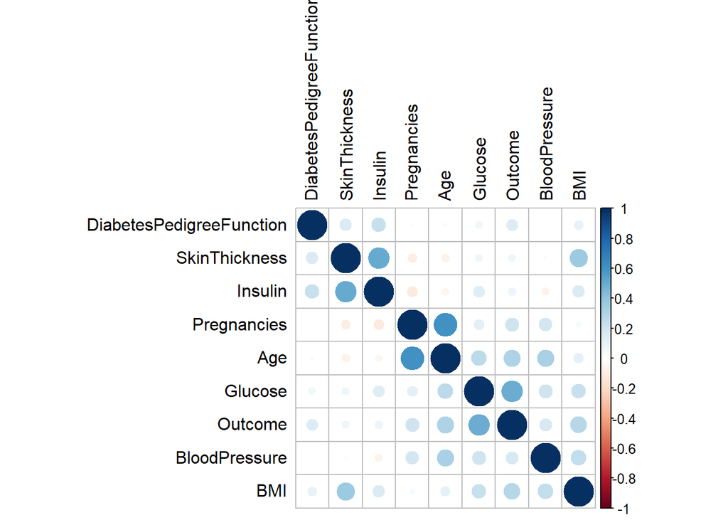

```r
par(mfrow=c(1,1))
corrplot(cor(datos), order = "hclust", tl.col='black', tl.cex=1)
```

Acto seguido, procederemos con el test de Bartlett, el cual parte de la hipótesis nula de que la matriz de covarianzas es la identidad, esto es, las variables son independientes.

```r
# Se normalizan los datos
datos_normalizados<-scale(datos)
# Se hace el test de esfericidad
cortest.bartlett(cor(datos_normalizados), n = nrow(datos))
```

```
## $chisq
## [1] 1287.969
##
## $p.value
## [1] 3.408574e-247
##
## $df
## [1] 36
```

Como podemos observar, el test sale significativo y por ende la hipótesis nula que afirma que la matriz de correlaciones es la identidad queda descartada. Al haber relación entre las variables, tiene sentido plantearse análisis ACP o AF.

# Reducción de la dimensión mediante un análisis de componentes principales

Procedemos pues a aplicarle ACP ya que previamente hemos arreglado los datos outliers.

```r
# Realización del ACP
PCA<-prcomp(datos, scale=T, center = T)

# El campo "rotation" del objeto "PCA" es una matriz cuyas columnas
# son los coeficientes de las componentes principales, es decir, el
# peso de cada variable en la correspondiente componente principal
PCA$rotation
```

```
##                                 PC1         PC2          PC3        PC4
## Pregnancies              -0.3415688  0.37165432 -0.401744885  0.3035937
## Glucose                  -0.4249838 -0.04469974  0.191233986 -0.5129747
## BloodPressure            -0.3403342  0.13697074  0.378881726  0.3450804
## SkinThickness            -0.1581597 -0.54743653 -0.009576352  0.3763234
## Insulin                  -0.1296444 -0.53369599 -0.275970590  0.1013121
## BMI                      -0.3469732 -0.27586581  0.403622638  0.2230722
## DiabetesPedigreeFunction -0.1363657 -0.27117885 -0.580805758 -0.2079399
## Age                      -0.4421807  0.32626089 -0.280075291  0.2185585
## Outcome                  -0.4588684 -0.02257801  0.059489854 -0.4826550
##                                  PC5         PC6         PC7         PC8
## Pregnancies              -0.20077709  0.20492539 -0.06672533 -0.16545027
## Glucose                  -0.21854405 -0.29633091 -0.54219188 -0.29084399
## BloodPressure             0.44943346 -0.57065476  0.22077327 -0.01808132
## SkinThickness            -0.20356364  0.06168041  0.18406297 -0.64673774
## Insulin                  -0.32943125 -0.38793340  0.01775934  0.56089097
## BMI                       0.19961463  0.57500860 -0.33644405  0.32325620
## DiabetesPedigreeFunction  0.70846172  0.01862250 -0.11958681 -0.10347638
## Age                      -0.11733228 -0.04735418 -0.08883402  0.18152562
## Outcome                  -0.06665314  0.23880078  0.69516416  0.08177519
##                                  PC9
## Pregnancies               0.61441342
## Glucose                   0.05951006
## BloodPressure             0.16147672
## SkinThickness            -0.19025299
## Insulin                   0.19495048
## BMI                       0.05162520
## DiabetesPedigreeFunction -0.00435049
## Age                      -0.71761252
## Outcome                   0.03203521
```

```r
# En el campo "sdev" del objeto "PCA" y con la función summary aplicada
# al objeto, obtenemos información relevante: desviaciones típicas de
# cada componente principal, proporción de varianza explicada y acumulada.
PCA$sdev
```

```
## [1] 1.5263327 1.3652489 1.0077548 0.9996625 0.9173911 0.8367940 0.6827611
## [8] 0.6467734 0.6043174
```

```r
summary(PCA)
```

```
## Importance of components:
##                           PC1    PC2    PC3    PC4     PC5    PC6    PC7
## Standard deviation     1.5263 1.3652 1.0078 0.9997 0.91739 0.8368 0.6828
## Proportion of Variance 0.2589 0.2071 0.1128 0.1110 0.09351 0.0778 0.0518
## Cumulative Proportion  0.2589 0.4660 0.5788 0.6898 0.78334 0.8611 0.9129
##                            PC8     PC9
## Standard deviation     0.64677 0.60432
## Proportion of Variance 0.04648 0.04058
## Cumulative Proportion  0.95942 1.00000
```

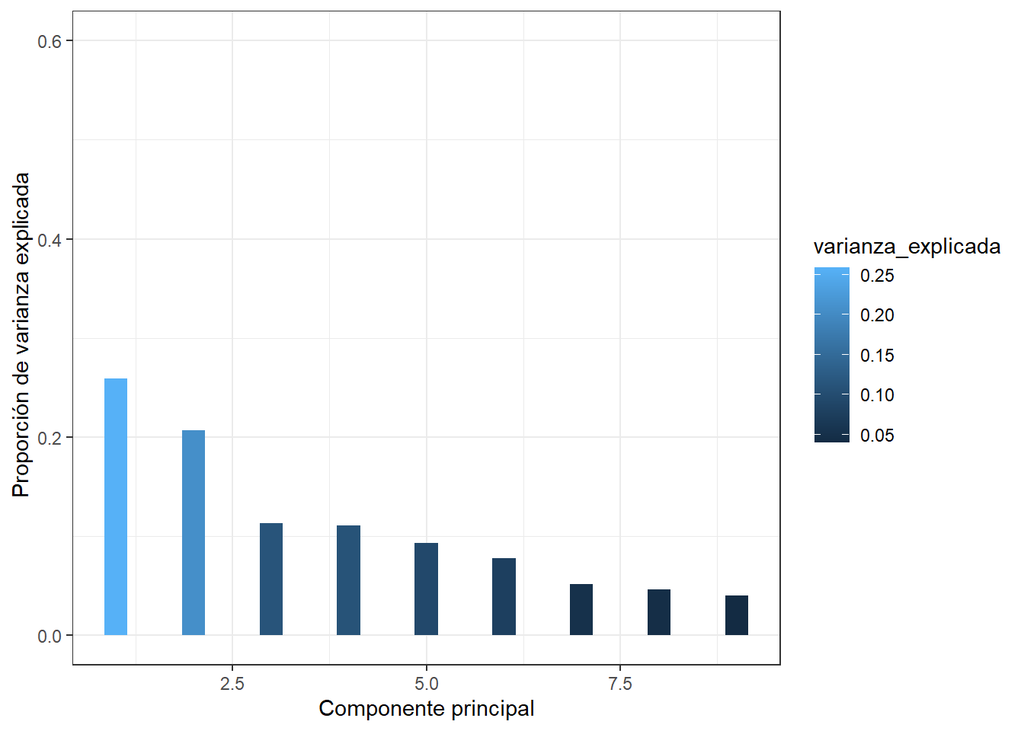

```r
par(mfrow=c(1,1))

# Proporción de varianza explicada
varianza_explicada <- PCA$sdev^2 / sum(PCA$sdev^2)
ggplot(data = data.frame(varianza_explicada, pc = 1:ncol(datos)),
       aes(x = pc, y = varianza_explicada, fill=varianza_explicada )) +
  geom_col(width = 0.3) +
  scale_y_continuous(limits = c(0,0.6)) + theme_bw() +
  labs(x = "Componente principal", y= " Proporción de varianza explicada")
```

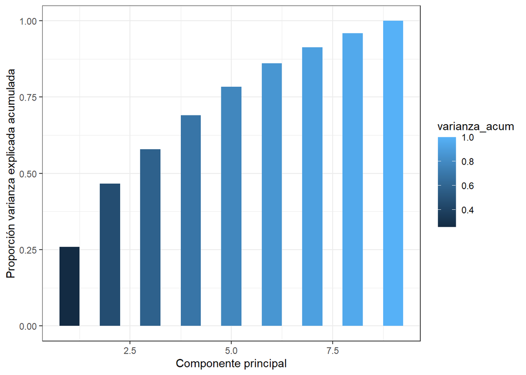

```r
# Proporción de varianza explicada acumulada
varianza_acum<-cumsum(varianza_explicada)
ggplot( data = data.frame(varianza_acum, pc = 1:ncol(datos)),
        aes(x = pc, y = varianza_acum ,fill=varianza_acum )) +
  geom_col(width = 0.5) +
  scale_y_continuous(limits = c(0,1)) +
  theme_bw() +
  labs(x = "Componente principal",
       y = "Proporción varianza explicada acumulada")
```

Ahora debemos elegir cuántas componentes principales vamos a elegir. Utilizaremos la Regla de Abdi para ver la media de las varianzas explicadas por las componentes principales y seleccionar aquellas cuya proporción de varianza explicada supere a dicha media.

```r
PCA$sdev^2
```

```
## [1] 2.3296916 1.8639047 1.0155696 0.9993252 0.8416065 0.7002243 0.4661628
## [8] 0.4183159 0.3651995
```

```r
mean(PCA$sdev^2)
```

```
## [1] 1
```

Podemos observar que solo las 3 primeras componentes principales superan la media obtenida, aunque consideramos que incluir la cuarta componente sería beneficioso dada la cercanía a la media y que con solo 3 componentes principales la varianza acumulada explicada sería de 0.5788 mientras que añadiendo la cuarta sería de 0.6898.

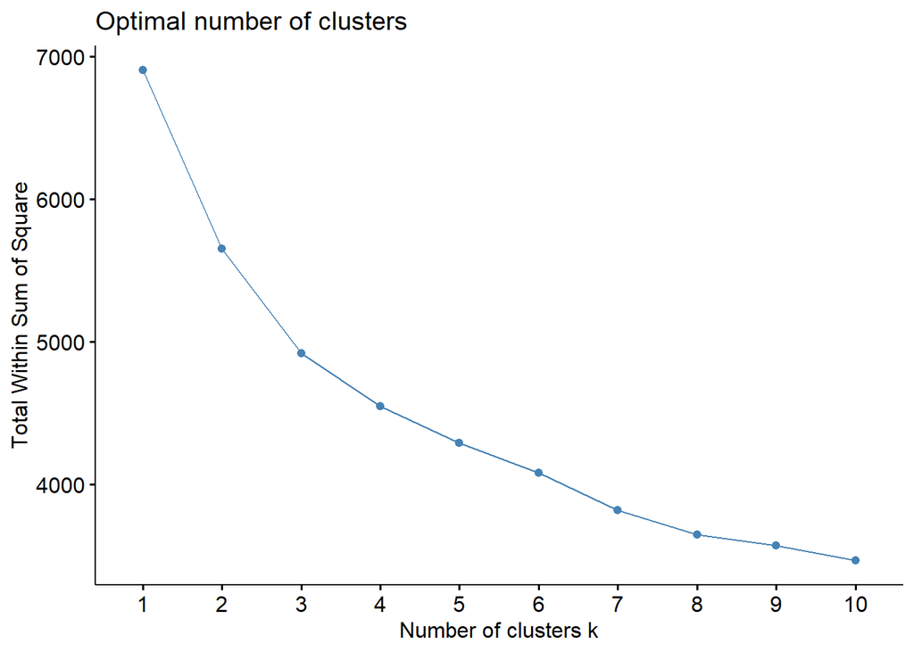

```r
fviz_nbclust(scale(datos), kmeans, method = 'wss')
```

# Reducción de la dimensión mediante un análisis factorial

Como ya hemos visto en el apartado anterior, tiene sentido plantear un análisis factorial.

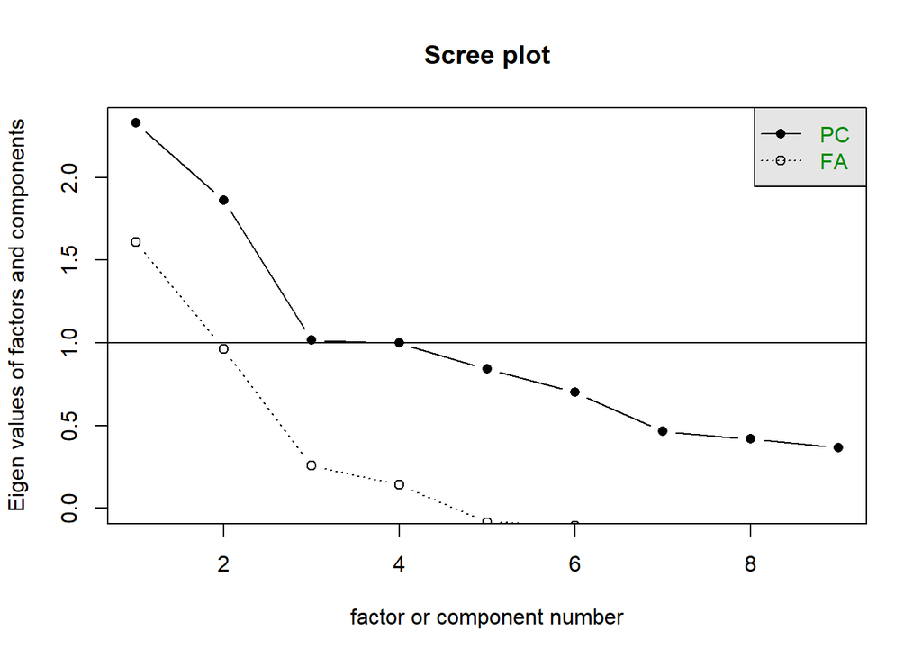

```r
scree(poly_cor)
```

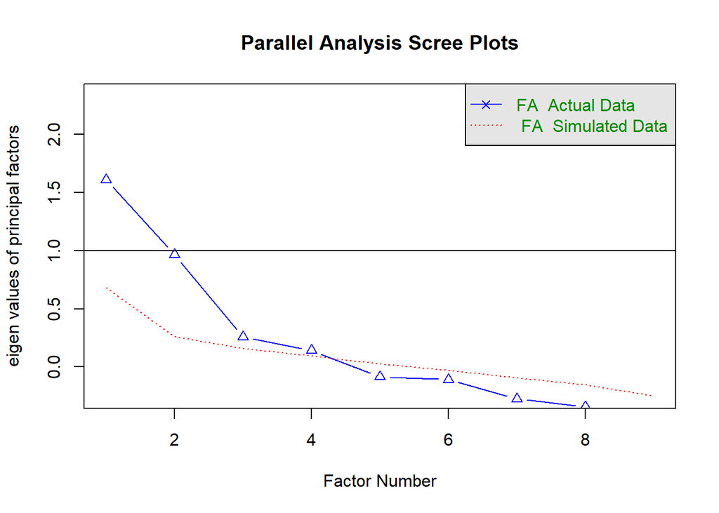

```
## Parallel analysis suggests that the number of factors =  4  and the number of components =  NA
```

```r
fa.parallel(poly_cor,n.obs=200,fa="fa",fm="minres")
```

Observando el gráfico y el resultado del análisis paralelo, el número óptimo de factores es 4.

```r
modelo1<-fa(poly_cor,
            nfactors = 4,
            rotate = "none",
            fm="mle") # modelo m?xima verosimilitud

modelo2<-fa(poly_cor,
            nfactors = 4,
            rotate = "none",
            fm="minres") # modelo m?nimo residuo
```

Comparando las comunalidades

```r
sort(modelo1$communality,decreasing = T)->c1
sort(modelo2$communality,decreasing = T)->c2
head(cbind(c1,c2))
```

```
##                      c1        c2
## Glucose       0.9950001 0.9972445
## BMI           0.9611265 0.8547319
## Age           0.9136844 0.7890546
## Insulin       0.8782039 0.6505318
## Pregnancies   0.4047152 0.4145521
## SkinThickness 0.3838274 0.3786802
```

Comparacion de las unicidades, es decir la proporción de varianza que no ha sido explicada por el factor (1-comunalidad)

```r
sort(modelo1$uniquenesses,decreasing = T)->u1
sort(modelo2$uniquenesses,decreasing = T)->u2
head(cbind(u1,u2))
```

```
##                                 u1        u2
## DiabetesPedigreeFunction 0.9367988 0.9255177
## BloodPressure            0.8247396 0.8235743
## Outcome                  0.6880120 0.6327549
## SkinThickness            0.6161726 0.6213198
## Pregnancies              0.5952848 0.5854479
## Insulin                  0.1217961 0.3494682
```

# Análisis discriminante: Clasificadores

## Análisis de la normalidad multivariante

```r
#outliers <- mvn(data = datos[,-1], mvnTest = "hz", multivariateOutlierMethod = "quan")
```

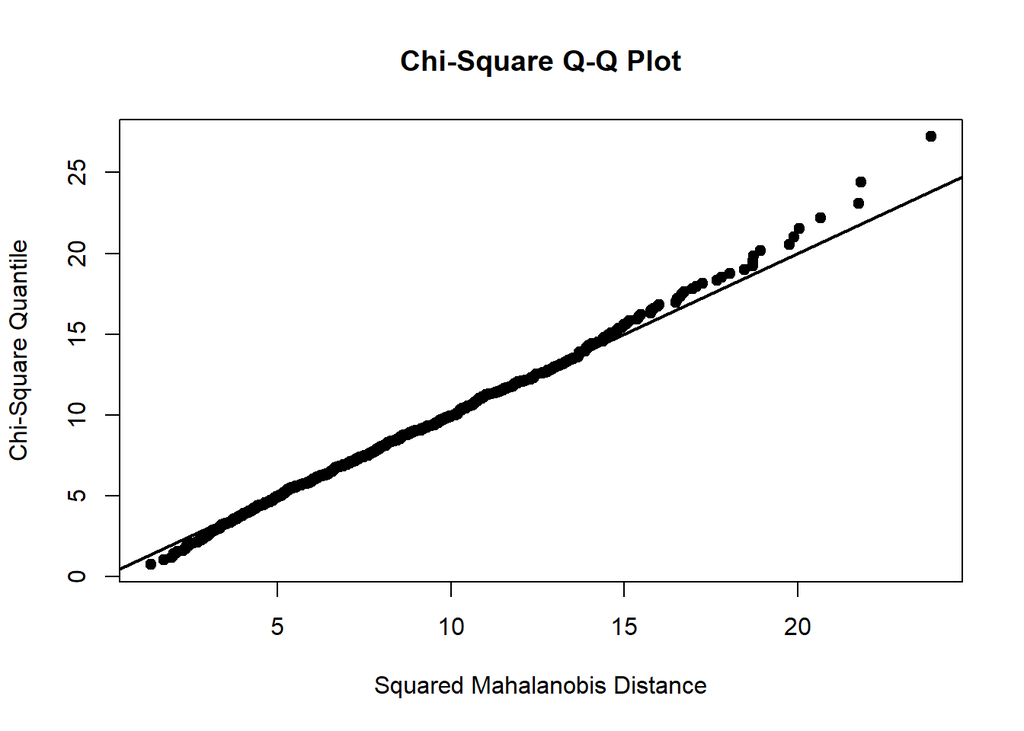

```r
royston_test <- mvn(data = datos[,-1], mvnTest = "royston", multivariatePlot = "qq")
```

```r
royston_test$multivariateNormality
```

```
##      Test       H       p value MVN
## 1 Royston 623.722 2.076315e-129  NO
```

```r
hz_test <- mvn(data = datos[,-1], mvnTest = "hz")
hz_test$multivariateNormality
```

```
##            Test       HZ p value MVN
## 1 Henze-Zirkler 2.516848       0  NO
```

## Clasificadores

### Lineal

```r
modelo_lda <- lda(formula = Outcome ~ Pregnancies + Glucose + BloodPressure + SkinThickness + Insulin + BMI + DiabetesPedigreeFunction + Age,data = datos)
modelo_lda
```

```
## Call:
## lda(Outcome ~ Pregnancies + Glucose + BloodPressure + SkinThickness +
##     Insulin + BMI + DiabetesPedigreeFunction + Age, data = datos)
##
## Prior probabilities of groups:
##         0         1
## 0.6510417 0.3489583
##
## Group means:
##   Pregnancies  Glucose BloodPressure SkinThickness  Insulin      BMI
## 0    3.298000 110.7101      70.79475      19.66400 52.13032 30.79349
## 1    4.698308 142.1656      74.59517      21.87102 62.93126 34.57407
##   DiabetesPedigreeFunction      Age
## 0                0.3879774 29.90435
## 1                0.4529204 36.32802
##
## Coefficients of linear discriminants:
##                                    LD1
## Pregnancies               0.0444029075
## Glucose                   0.0287884526
## BloodPressure            -0.0040980695
## SkinThickness            -0.0022288155
## Insulin                  -0.0003010238
## BMI                       0.0617628796
## DiabetesPedigreeFunction  1.0275757386
## Age                       0.0297898332
```

### Cuadrático

```r
modelo_qda <- qda(formula = Outcome ~ Pregnancies + Glucose + BloodPressure + SkinThickness + Insulin + BMI + DiabetesPedigreeFunction + Age,data = datos)
modelo_qda
```

```
## Call:
## qda(Outcome ~ Pregnancies + Glucose + BloodPressure + SkinThickness +
##     Insulin + BMI + DiabetesPedigreeFunction + Age, data = datos)
##
## Prior probabilities of groups:
##         0         1
## 0.6510417 0.3489583
##
## Group means:
##   Pregnancies  Glucose BloodPressure SkinThickness  Insulin      BMI
## 0    3.298000 110.7101      70.79475      19.66400 52.13032 30.79349
## 1    4.698308 142.1656      74.59517      21.87102 62.93126 34.57407
##   DiabetesPedigreeFunction      Age
## 0                0.3879774 29.90435
## 1                0.4529204 36.32802
```

## Resultados de los Clasificadores

```r
pred <- predict(modelo_lda, dimen = 1)
confusionmatrix(datos$Outcome, pred$class)
```

```
##   new 0 new 1
## 0   441    59
## 1   116   152
```

```r
# Porcentaje de errores de clasificación
trainig_error <- mean(datos$Outcome != pred$class) * 100
paste("trainig_error=", trainig_error, "%")
```

```
## [1] "trainig_error= 22.7864583333333 %"
```

```r
pred <- predict(modelo_qda, dimen = 1)
confusionmatrix(datos$Outcome, pred$class)
```

```
##   new 0 new 1
## 0   425    75
## 1    98   170
```

```r
# Porcentaje de errores de clasificación
trainig_error <- mean(datos$Outcome != pred$class) * 100
paste("trainig_error=", trainig_error, "%")
```

```
## [1] "trainig_error= 22.5260416666667 %"
```